# Test a Perceptual Phenomenon

### Analyzing the Stroop Effect

Perform the analysis in the space below. Remember to follow [the instructions](https://docs.google.com/document/d/1-OkpZLjG_kX9J6LIQ5IltsqMzVWjh36QpnP2RYpVdPU/pub?embedded=True) and review the [project rubric](https://review.udacity.com/#!/rubrics/71/view) before submitting. Once you've completed the analysis and write-up, download this file as a PDF or HTML file, upload that PDF/HTML into the workspace here (click on the orange Jupyter icon in the upper left then Upload), then use the Submit Project button at the bottom of this page. This will create a zip file containing both this .ipynb doc and the PDF/HTML doc that will be submitted for your project.

(1) What is the independent variable? What is the dependent variable?

Independent Variable: The color of the word that similar or different from it meaning  
Dependent Variable: Time taken to finish the two Stroop tasks (congruent and incongruent).

(3) Report some descriptive statistics regarding this dataset. Include at least one measure of central tendency and at least one measure of variability. The name of the data file is 'stroopdata.csv'.

```python
import pandas as pd
import scipy.stats as stats
import matplotlib.pyplot as plt
%matplotlib inline
```

```python
data = pd.read_csv('stroopdata.csv')
```

```python
data.mean()
```

```
Congruent      14.051125
Incongruent    22.015917
dtype: float64
```

```python
data.std()
```

```
Congruent      3.559358
Incongruent    4.797057
dtype: float64
```

I used mean for the measure of central tendency and standard deviation for measure of variability.  
Mean for Congruent: 14.051125  
Mean for Incongruent: 22.015917  
Standard Deviation for Congruent: 3.559358  
Standard Deviation for Incongruent: 4.797057

(4) Provide one or two visualizations that show the distribution of the sample data. Write one or two sentences noting what you observe about the plot or plots.

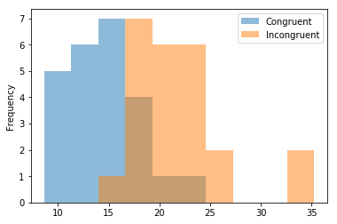

```python
# Build the visualizations here
data.plot(kind="hist", alpha =0.5);
```

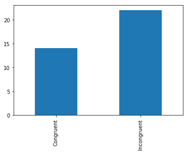

```python
data.mean().plot('bar');
```

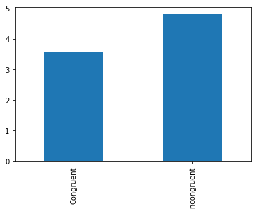

```python
data.std().plot('bar');
```

First Plot: Both time taken to finish congruent and incongruent task are not normal distributed.  
Second Plot: Average time taken to finish the congruent task is shorter than incongruent task.  
Third Plot: The spread of time taken to finish for congruent task is tigher than incongruent task.

(5) Now, perform the statistical test and report your results. What is your confidence level or Type I error associated with your test? What is your conclusion regarding the hypotheses you set up? Did the results match up with your expectations? **Hint:** Think about what is being measured on each individual, and what statistic best captures how an individual reacts in each environment.

```python
# Perform the statistical test here
# Set columns to lists to use in ttest function
congruent = data['Congruent'].values.tolist()
incongruent = data['Incongruent'].values.tolist()
```

```python
stats.ttest_rel(congruent,incongruent)
```

```
Ttest_relResult(statistic=-8.020706944109957, pvalue=4.1030005857111781e-08)
```

Let use a 5% confidence level for statistical significance. The p-value is 4.1030005857111781e-08 which is very small and close to 0. As a result we reject the null hypothesis and the results did match up our expectation.

(6) Optional: What do you think is responsible for the effects observed? Can you think of an alternative or similar task that would result in a similar effect? Some research about the problem will be helpful for thinking about these two questions!

Stroop effect did measure participants attention and processing speed ability. I think similar task would be like working with complicated 2D and 3D objects.